# AS04_Data-Manipulation-Joining_ref

曾子軒 Teaching Assistant

2021/03/23

## 作業目的: Data Manipulation and Joining

這份作業希望能夠讓你熟悉於資料處理(data manipulation)，利用這兩週所學的 filter, mutate, select, group by, summarize, join, pivot 等動詞完成任務。請一律印出 tibble，你可以利用 `as_tibble()` 將 dataframe 轉換成 tibble，不過按照預設的 code 應該都會是 tibble，另外印出結果不用特別打 `print()` 喔。作業的滿分為 100 分。

老師在影片中示範怎麼處理各村里的婚姻狀況，清理後再與公投資料串接，這次的作業則是要處理教育資料，資料中包含全台各村里 **15歲以上現住人口** 的性別、年齡、教育程度統計。請一定要先看影片再來寫！

## 作業: Data Manipulation and Joining

```r
### 這邊不要動
library(tidyverse)
df_education_raw <- read_csv("data/AS04/opendata107Y020.csv")
### 給你看資料長這樣
df_education_raw %>% glimpse()
```

```
#> Rows: 7,761
#> Columns: 51
#> $ statistic_yyy                               <chr> "統計年", "107", "107", "107"…
#> $ district_code                               <chr> "區域別代碼", "65000010001", "6…
#> $ site_id                                     <chr> "區域別", "新北市板橋區", "新北市板橋區",…
#> $ village                                     <chr> "村里名稱", "留侯里", "流芳里", "赤松里…
#> $ edu_age_15up_total                          <chr> "總計", "1431", "1337", "707…
#> $ edu_doctor_graduated_m                      <chr> "博畢_男", "4", "7", "5", "2"…
#> $ edu_doctor_graduated_f                      <chr> "博畢_女", "0", "3", "1", "2"…
#> $ edu_doctor_ungraduated_m                    <chr> "博肄_男", "1", "2", "0", "3"…
#> $ edu_doctor_ungraduated_f                    <chr> "博肄_女", "2", "2", "0", "0"…
#> $ edu_master_graduated_m                      <chr> "碩畢_男", "52", "48", "31", …
#> $ edu_master_graduated_f                      <chr> "碩畢_女", "31", "39", "32", …
#> $ edu_master_ungraduated_m                    <chr> "碩肄_男", "12", "16", "6", "…
#> $ edu_master_ungraduated_f                    <chr> "碩肄_女", "7", "14", "2", "3…
```

[output cut: 38 more lines]

將資料讀進來之後可以看到這份資料的長相，前幾列是村里的名稱與代碼，後面以 `edu_` 開頭的欄位則是代表該村里教育相關的狀態。舉例來說，`edu_doctor_graduated_m` 代表的是 `博畢_男`，`edu_juniorcollege_2ys_ungraduated_f` 代表的是 `二肄_女`，`edu_selftaughtl_m` 代表的是 `自修_男`，`edu_juniorcollege_5ys_first3y_ungraduated_f` 代表的是 `前三肄_女`。

「2畢」、「2肄」、「後3畢」、「後3肄」、「前3肄」於教育程度統計上分別指專科2、3年制、5專、5專後2年、5專前3年之畢業、肄業狀況。另外，肄業包含中途輟學、休學者，或正在學校求學之學生，所以在學生也算在裡面喔！

```r
### 這邊不要動
df_education <- df_education_raw %>%
  slice(-1) %>%
  select(-edu_age_15up_total, -statistic_yyy) %>%
  mutate(across(contains("edu_"), ~as.integer(.)))
```

我把第一列刪掉後，再將用不到的欄位刪除，並且把教育相關欄位轉換成整數，接下來請用 `df_education` 作答！

### 1. `pivot_longer()`:

現在的資料是一個寬表格(wide)，請利用 `pivot_longer()` 或是 `gather()` 將它轉換成長表格(long)，儲存為 `df_education_long` ，並將 `df_education_long` 印出。

```r
### your code
df_education_long <- df_education %>%
  pivot_longer(cols = -c(1:3), names_to = "key", values_to = "value")

df_education_long
### your result should be
```

```
#> # A tibble: 356,960 x 5
#>    district_code site_id      village key                        value
#>    <chr>         <chr>        <chr>   <chr>                      <int>
#>  1 65000010001   新北市板橋區 留侯里  edu_doctor_graduated_m         4
#>  2 65000010001   新北市板橋區 留侯里  edu_doctor_graduated_f         0
#>  3 65000010001   新北市板橋區 留侯里  edu_doctor_ungraduated_m       1
#>  4 65000010001   新北市板橋區 留侯里  edu_doctor_ungraduated_f       2
#>  5 65000010001   新北市板橋區 留侯里  edu_master_graduated_m        52
#>  6 65000010001   新北市板橋區 留侯里  edu_master_graduated_f        31
#>  7 65000010001   新北市板橋區 留侯里  edu_master_ungraduated_m      12
#>  8 65000010001   新北市板橋區 留侯里  edu_master_ungraduated_f       7
#>  9 65000010001   新北市板橋區 留侯里  edu_university_graduated_m   150
#> 10 65000010001   新北市板橋區 留侯里  edu_university_graduated_f   167
#> # … with 356,950 more rows
```

### 2. `separate()`:

請觀察 `df_education_long` 當中 `key` 欄位的值，將 key 利用 `separate()` 切開成四個欄位，分別是`edu`, `level`, `edu_status`, `gender`，各自代表教育前綴詞、學位、教育狀態、性別。最後將結果儲存在 `df_education_long_cut` 當中，並將 `df_education_long_cut` 印出。如果你不懂這邊在說什麼，請參考老師本週第一支影片(R04_1_1 Loading MOI demographic data)，基本上就是按照裡面的流程進行。底下會遇到好切跟不好切的情況，遇到不好切的情況時可以使用 `str_replace()` 函數。

提示：

1. 你可以利用 `count()` 觀察 `key` 的結構。舉例來說， `edu_doctor_graduated_m` 應該切成 `edu` = “edu”, `level` = “doctor”, `edu_status` = “graduated”, `gender` = “m”。
2. 不好切的情況(01)： `edu_illiterate_f` 代表不識字，沒辦法切成四塊，請想辦法將這個值切成 `edu` = “edu”, `level` = “illiterate”, `edu_status` = “all”, `gender` = “f”。
3. 不好切的情況(02)： `edu_juniorcollege_2ys_graduated_m` 裡面多了一個 `_`，同樣沒辦法切成四塊，請想辦法將這個值切成 `edu` = “edu”, `level` = “juniorcollege2ys”, `edu_status` = “graduated”, `gender` = “m”。
4. `str_replace(string = "小軒不喜歡吃肉", pattern = "不喜歡", replacement = "超討厭")` 的意思是把 `string` 參數當中滿足 `pattern` 參數的字串替換成 `replacement` 參數的值，所以結果會是 `"小軒超討厭吃肉"`。

```r
### 這邊讓你看 key 的長相
df_education_long %>% count(key)

### your result should be
### your code
df_education_long_cut <- df_education_long %>%
  mutate(key = str_replace(key, "juniorcollege_2ys", "juniorcollege2ys")) %>%
  mutate(key = str_replace(key, "juniorcollege_5ys_final2y", "juniorcollege5ysfinal2y")) %>%
  mutate(key = str_replace(key, "juniorcollege_5ys_final3y", "juniorcollege5ysfinal3y")) %>%
  mutate(key = str_replace(key, "juniorcollege_5ys_first3y", "juniorcollege5ysfirst3y")) %>%
  mutate(key = str_replace(key, "_illiterate", "_illiterate_all")) %>%
  mutate(key = str_replace(key, "_selftaughtl", "_selftaughtl_all")) %>%
  separate(key, c("edu", "level", "graduate", "gender"), sep = "_")

df_education_long_cut

### your result should be
```

```
#> # A tibble: 46 x 2
#>    key                          n
#>  * <chr>                    <int>
#>  1 edu_doctor_graduated_f    7760
#>  2 edu_doctor_graduated_m    7760
#>  3 edu_doctor_ungraduated_f  7760
#>  4 edu_doctor_ungraduated_m  7760
#>  5 edu_illiterate_f          7760
#>  6 edu_illiterate_m          7760
#>  7 edu_junior_graduated_f    7760
#>  8 edu_junior_graduated_m    7760
#>  9 edu_junior_ungraduated_f  7760
#> 10 edu_junior_ungraduated_m  7760
#> # … with 36 more rows
#> # A tibble: 356,960 x 8
#>    district_code site_id      village edu   level      graduate    gender value
#>    <chr>         <chr>        <chr>   <chr> <chr>      <chr>       <chr>  <int>
#>  1 65000010001   新北市板橋區 留侯里  edu   doctor     graduated   m          4
#>  2 65000010001   新北市板橋區 留侯里  edu   doctor     graduated   f          0
#>  3 65000010001   新北市板橋區 留侯里  edu   doctor     ungraduated m          1
#>  4 65000010001   新北市板橋區 留侯里  edu   doctor     ungraduated f          2
#>  5 65000010001   新北市板橋區 留侯里  edu   master     graduated   m         52
#>  6 65000010001   新北市板橋區 留侯里  edu   master     graduated   f         31
#>  7 65000010001   新北市板橋區 留侯里  edu   master     ungraduated m         12
#>  8 65000010001   新北市板橋區 留侯里  edu   master     ungraduated f          7
#>  9 65000010001   新北市板橋區 留侯里  edu   university graduated   m        150
#> 10 65000010001   新北市板橋區 留侯里  edu   university graduated   f        167
#> # … with 356,950 more rows
```

### 3. `group_by()` and `summarize()`:

請計算以區域別(site_id) 為單位的教育統計，產出的欄位包含 n_sum(15歲以上現住人口總人數), n_female(女性15歲以上現住人口總人數), n_higher(高等教育總人數, 包含博士、碩士、大學，畢業與肄業皆計入), n_higher_female(女性高等教育總人數), n_self(自學總人數), n_illiterate(不識字總人數)，把資料儲存為 `df_education_agg`，並且將 `df_education_agg` 印出。

```r
### your code
df_education_agg <- df_education_long_cut %>%
  group_by(site_id) %>%
  summarise(n_sum = sum(value),
            n_female = sum(value[gender == "f"]),
            n_higher = sum(value[level %in% c("doctor", "master", "university")]),
            n_higher_female = sum(value[level %in% c("doctor", "master", "university") & gender == "f"]),
            n_self = sum(value[level == "selftaughtl"]),
            n_illiterate = sum(value[level == "illiterate"]))

df_education_agg

### your result should be
```

```
#> # A tibble: 370 x 7
#>    site_id      n_sum n_female n_higher n_higher_female n_self n_illiterate
#>  * <chr>        <int>    <int>    <int>           <int>  <int>        <int>
#>  1 南投縣中寮鄉 13571     6187     2339            1141     38          380
#>  2 南投縣仁愛鄉 13158     6386     2029            1088     31           51
#>  3 南投縣信義鄉 13847     6418     2482            1210     64           76
#>  4 南投縣南投市 87696    44119    28352           13650     88          791
#>  5 南投縣名間鄉 34622    16354     7706            3726    108          306
#>  6 南投縣國姓鄉 17132     7860     2937            1386     34          410
#>  7 南投縣埔里鎮 71529    36009    17679            8941     99          749
#>  8 南投縣水里鄉 15960     7561     3131            1489     38          266
#>  9 南投縣竹山鎮 48789    23780    11115            5336    785            0
#> 10 南投縣草屯鎮 86210    42768    25906           12396    135         1040
#> # … with 360 more rows
```

### 4. data joining:

請以教育資料為基底，串接第十案公投的資料。串接後會發現兩邊資料大部分可以完成串接，但有少部分會有問題，請檢查到底問題在哪裡，將問題排除後，將串好的資料儲存成 `df_ref_edu_join`，再將 `df_ref_edu_join` 印出。

提示：

1. 你可以在串好之後，利用 `filter(is.na(填你要檢查的欄位))` 檢查是哪些列有問題。
2. 發現 `site_id` 的問題之後，你會回頭重新利用 `group_by()` 和 `summarize()` 計算教育統計，再去 join 公投案資料。

```r
### 這裡不要動
ref10 <- read_csv("data/AS04/ref10_town.csv") %>%
  select(county = 縣市, town = 鄉鎮市區,
         agree = 同意票數, disagree = 不同意票數,
         legalVote = 有效票數, illegalVote = 無效票數,
         vote = 投票數, legalPopulation =  投票權人數)  %>%
  mutate(site_id = str_c(county, town)) %>%
  select(-c(county, town)) %>%
  drop_na(site_id) %>% select(site_id, everything())

### your code
df_education_agg %>% left_join(ref10) %>%
  filter(is.na(legalPopulation))

df_ref_edu_join <-
  df_education_agg %>%
  mutate(site_id = str_remove_all(site_id, " |　")) %>%
  mutate(site_id = case_when(
    str_detect(site_id, "高雄市鳳山") ~ "高雄市鳳山區",
    str_detect(site_id, "高雄市三民") ~ "高雄市三民區",
    TRUE ~ site_id
  )) %>%
  group_by(site_id) %>%
  summarise(across(contains("n_"), ~sum(.))) %>%
  left_join(ref10)

df_ref_edu_join

### your result should be
```

```
#> # A tibble: 16 x 13
#>    site_id     n_sum n_female n_higher n_higher_female n_self n_illiterate agree
#>    <chr>       <int>    <int>    <int>           <int>  <int>        <int> <dbl>
#>  1 嘉義市東　區… 105182    55143    40397           19894    195          917    NA
#>  2 嘉義市西　區… 126516    65445    42813           21093    164         1674    NA
#>  3 新竹市北　區… 128573    66399    51583           24554    184          883    NA
#>  4 新竹市東　區… 172265    88853    87811           41733    212          872    NA
#>  5 臺中市中　區…  15264     7759     5130            2499     23           58    NA
#>  6 臺中市北　區… 129168    68180    53046           26120    135          513    NA
#>  7 臺中市南　區… 108248    57055    46749           23674    176          427    NA
#>  8 臺中市東　區…  66792    33924    23149           11328     92          458    NA
#>  9 臺中市西　區…  99036    52767    45198           22567    145          351    NA
#> 10 臺南市北　區… 115147    59709    46231           22363    197          846    NA
#> 11 臺南市南　區… 112141    56919    37032           17795    477         1378    NA
#> 12 臺南市東　區… 159900    84356    74752           36548    121          737    NA
```

[output cut: 21 more lines]

### 5. data visualization:

請利用 `df_ref_edu_join`，計算 `agreeRate`(分母是 `legalVote`，分子是 `agree`) 以及 `per_higher` (分母是 `n_sum`，分子是 `n_higher`) ，接著利用 ggplot 和 geom_jitter() 畫出 x 軸 = `per_higher`, y 軸 = `agreeRate` 的散點圖，並用三行以內的文字**描述你的詮釋**。若不知道怎麼畫，請參考老師本週第四支影片(R04_1_4 Joining demographic and referendum data) 最後面。

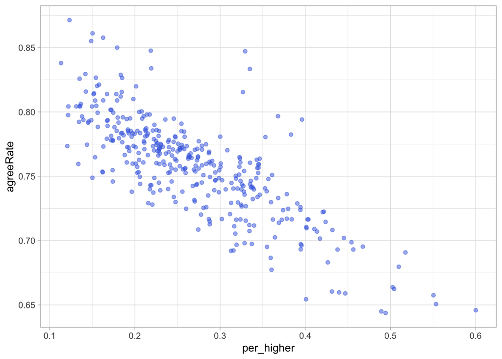

```r
### your code
df_ref_edu_join %>%
  mutate(agreeRate = agree / legalVote,
         per_higher = n_higher / n_sum) %>%
  ggplot() +
  aes(per_higher, agreeRate) +
  geom_jitter(alpha = 0.5, color = "royalblue") +
  theme_light()
```

```r
### your result should be
# 自己畫就好唷

### your text
# "高等教育程度人口比例和贊成公投第10案的投票人口比例呈現負相關，高等教育程度人口比例越高，贊成公投第10案的投票人口比例越低。"
```